# Problem 1: Linear Regression

You are hired by a company Gem Stones co ltd, which is a cubic zirconia manufacturer. You are provided with the dataset containing the prices and other attributes of almost 27,000 cubic zirconia (which is an inexpensive diamond alternative with many of the same qualities as a diamond). The company is earning different profits on different prize slots. You have to help the company in predicting the price for the stone on the bases of the details given in the dataset so it can distinguish between higher profitable stones and lower profitable stones so as to have better profit share. Also, provide them with the best 5 attributes that are most important.

### Data Dictionary:

**Variable Name - Description**  
**Carat** - Carat weight of the cubic zirconia.  
**Cut** - Describe the cut quality of the cubic zirconia. Quality is increasing order Fair, Good, Very Good, Premium, Ideal.  
**Color** - Colour of the cubic zirconia.With D being the worst and J the best.  
**Clarity** - cubic zirconia Clarity refers to the absence of the Inclusions and Blemishes. (In order from Worst to Best) IF, VVS1, VVS2, VS1, VS2, Sl1, Sl2, l1  
**Depth** - The Height of cubic zirconia, measured from the Culet to the table, divided by its average Girdle Diameter.  
**Table** - The Width of the cubic zirconia's Table expressed as a Percentage of its Average Diameter.  
**Price** - The Price of the cubic zirconia.  
**X** - Length of the cubic zirconia in mm.  
**Y** - Width of the cubic zirconia in mm.  
**Z** - Height of the cubic zirconia in mm.

## 1.1. Read the data and do exploratory data analysis. Describe the data briefly. (Check the null values, Data types, shape, EDA, duplicate values). Perform Univariate and Bivariate Analysis.

```python
# Loading nesscessary library for the model
```

```python
import pandas as pd
import numpy as np
# importing ploting libraries
import matplotlib.pyplot as plt
%matplotlib inline
# importing seaborn for statistical plots
import seaborn as sns
# Import Linear Regression machine learning library
from sklearn.model_selection import train_test_split
from sklearn.linear_model import LinearRegression
from sklearn.linear_model import Ridge
from sklearn.linear_model import Lasso
from sklearn import metrics

import scipy.stats as stats
```

```python
df = pd.read_csv('cubic_zirconia.csv')
```

```python
df.head()
```

|  | sno | carat | cut | color | clarity | depth | table | x | y | z | price |
| --- | --- | --- | --- | --- | --- | --- | --- | --- | --- | --- | --- |
| 0 | 1 | 0.30 | Ideal | E | SI1 | 62.1 | 58.0 | 4.27 | 4.29 | 2.66 | 499 |
| 1 | 2 | 0.33 | Premium | G | IF | 60.8 | 58.0 | 4.42 | 4.46 | 2.70 | 984 |
| 2 | 3 | 0.90 | Very Good | E | VVS2 | 62.2 | 60.0 | 6.04 | 6.12 | 3.78 | 6289 |
| 3 | 4 | 0.42 | Ideal | F | VS1 | 61.6 | 56.0 | 4.82 | 4.80 | 2.96 | 1082 |
| 4 | 5 | 0.31 | Ideal | F | VVS1 | 60.4 | 59.0 | 4.35 | 4.43 | 2.65 | 779 |

```python
df.shape
```

```
(26967, 11)
```

```python
df.info()
```

```
<class 'pandas.core.frame.DataFrame'>
RangeIndex: 26967 entries, 0 to 26966
Data columns (total 11 columns):
 #   Column   Non-Null Count  Dtype
---  ------   --------------  -----
 0   sno      26967 non-null  int64
 1   carat    26967 non-null  float64
 2   cut      26967 non-null  object
 3   color    26967 non-null  object
 4   clarity  26967 non-null  object
 5   depth    26270 non-null  float64
 6   table    26967 non-null  float64
 7   x        26967 non-null  float64
 8   y        26967 non-null  float64
 9   z        26967 non-null  float64
 10  price    26967 non-null  int64
dtypes: float64(6), int64(2), object(3)
memory usage: 2.3+ MB
```

```python
df=df.drop(['sno'], axis=1)
```

```python
df.describe(include = 'all').T
```

|  | count | unique | top | freq | mean | std | min | 25% | 50% | 75% | max |
| --- | --- | --- | --- | --- | --- | --- | --- | --- | --- | --- | --- |
| carat | 26967 | NaN | NaN | NaN | 0.798375 | 0.477745 | 0.2 | 0.4 | 0.7 | 1.05 | 4.5 |
| cut | 26967 | 5 | Ideal | 10816 | NaN | NaN | NaN | NaN | NaN | NaN | NaN |
| color | 26967 | 7 | G | 5661 | NaN | NaN | NaN | NaN | NaN | NaN | NaN |
| clarity | 26967 | 8 | SI1 | 6571 | NaN | NaN | NaN | NaN | NaN | NaN | NaN |
| depth | 26270 | NaN | NaN | NaN | 61.7451 | 1.41286 | 50.8 | 61 | 61.8 | 62.5 | 73.6 |
| table | 26967 | NaN | NaN | NaN | 57.4561 | 2.23207 | 49 | 56 | 57 | 59 | 79 |
| x | 26967 | NaN | NaN | NaN | 5.72985 | 1.12852 | 0 | 4.71 | 5.69 | 6.55 | 10.23 |
| y | 26967 | NaN | NaN | NaN | 5.73357 | 1.16606 | 0 | 4.71 | 5.71 | 6.54 | 58.9 |
| z | 26967 | NaN | NaN | NaN | 3.53806 | 0.720624 | 0 | 2.9 | 3.52 | 4.04 | 31.8 |
| price | 26967 | NaN | NaN | NaN | 3939.52 | 4024.86 | 326 | 945 | 2375 | 5360 | 18818 |

```python
dups = df.duplicated()
print('Number of duplicate rows = %d' % (dups.sum()))
df[dups]
```

```
Number of duplicate rows = 34
```

|  | carat | cut | color | clarity | depth | table | x | y | z | price |
| --- | --- | --- | --- | --- | --- | --- | --- | --- | --- | --- |
| 4756 | 0.35 | Premium | J | VS1 | 62.4 | 58.0 | 5.67 | 5.64 | 3.53 | 949 |
| 6215 | 0.71 | Good | F | SI2 | 64.1 | 60.0 | 0.00 | 0.00 | 0.00 | 2130 |
| 8144 | 0.33 | Ideal | G | VS1 | 62.1 | 55.0 | 4.46 | 4.43 | 2.76 | 854 |
| 8919 | 1.52 | Good | E | I1 | 57.3 | 58.0 | 7.53 | 7.42 | 4.28 | 3105 |
| 9818 | 0.35 | Ideal | F | VS2 | 61.4 | 54.0 | 4.58 | 4.54 | 2.80 | 906 |
| 10473 | 0.79 | Ideal | G | SI1 | 62.3 | 57.0 | 5.90 | 5.85 | 3.66 | 2898 |
| 10500 | 1.00 | Premium | F | VVS2 | 60.6 | 54.0 | 6.56 | 6.52 | 3.96 | 8924 |
| 12894 | 1.21 | Premium | D | SI2 | 62.5 | 57.0 | 6.79 | 6.71 | 4.22 | 6505 |
| 13547 | 0.43 | Ideal | G | VS1 | 61.9 | 55.0 | 4.84 | 4.86 | 3.00 | 943 |
| 13783 | 0.79 | Ideal | G | SI1 | 62.3 | 57.0 | 5.90 | 5.85 | 3.66 | 2898 |
| 14389 | 0.60 | Premium | D | SI2 | 62.0 | 57.0 | 5.43 | 5.35 | 3.34 | 1196 |
| 14410 | 1.00 | Very Good | D | SI1 | 63.1 | 56.0 | 6.34 | 6.30 | 3.99 | 5645 |
| 15798 | 0.90 | Very Good | I | VS2 | 58.4 | 62.0 | 6.29 | 6.35 | 3.69 | 3334 |
| 16852 | 0.79 | Ideal | G | SI1 | 62.3 | 57.0 | 5.90 | 5.85 | 3.66 | 2898 |
| 17263 | 1.04 | Premium | I | SI2 | 62.0 | 57.0 | 6.53 | 6.47 | 4.03 | 3774 |
| 18025 | 1.51 | Good | I | SI1 | 63.8 | 57.0 | 7.21 | 7.18 | 4.59 | 6046 |
| 18777 | 0.32 | Premium | H | VS2 | 60.6 | 58.0 | 4.47 | 4.44 | 2.70 | 648 |
| 18837 | 1.01 | Premium | H | VS1 | 61.2 | 61.0 | 6.44 | 6.41 | 3.93 | 5294 |
| 19731 | 0.30 | Good | J | VS1 | 63.4 | 57.0 | 4.23 | 4.26 | 2.69 | 394 |
| 19877 | 2.01 | Premium | I | VS2 | 60.3 | 62.0 | 8.13 | 8.08 | 4.89 | 15939 |
| 20301 | 0.30 | Ideal | H | SI1 | 62.2 | 57.0 | 4.26 | 4.29 | 2.66 | 450 |
| 20760 | 1.80 | Ideal | H | VS1 | 62.3 | 56.0 | 7.79 | 7.76 | 4.84 | 15105 |
| 22322 | 2.05 | Premium | I | SI2 | 62.0 | 58.0 | 8.13 | 8.08 | 5.02 | 9850 |
| 22488 | 2.42 | Premium | J | VS2 | 61.3 | 59.0 | 8.61 | 8.58 | 5.27 | 17168 |
| 22583 | 0.33 | Ideal | F | IF | 61.2 | 56.0 | 4.47 | 4.49 | 2.74 | 1240 |
| 23458 | 2.66 | Good | H | SI2 | 63.8 | 57.0 | 8.71 | 8.65 | 5.54 | 16239 |
| 23564 | 1.50 | Premium | F | SI2 | 58.5 | 60.0 | 7.52 | 7.48 | 4.39 | 7644 |
| 24351 | 2.50 | Fair | H | SI2 | 64.9 | 58.0 | 8.46 | 8.43 | 5.48 | 13278 |
| 24816 | 1.50 | Good | G | SI2 | 57.5 | 63.0 | 7.53 | 7.49 | 4.32 | 6006 |
| 25268 | 1.20 | Premium | I | VS2 | 62.6 | 58.0 | 6.77 | 6.72 | 4.22 | 5699 |
| 25759 | 0.30 | Ideal | G | IF | 62.1 | 55.0 | 4.32 | 4.35 | 2.69 | 863 |
| 25941 | 0.51 | Premium | F | SI2 | 58.1 | 59.0 | 5.26 | 5.24 | 3.05 | 1052 |
| 26191 | 2.54 | Very Good | H | SI2 | 63.5 | 56.0 | 8.68 | 8.65 | 5.50 | 16353 |
| 26530 | 0.41 | Ideal | G | IF | 61.7 | 56.0 | 4.77 | 4.80 | 2.95 | 1367 |

```python
df.drop_duplicates(inplace=True)
```

```python
df.shape
```

```
(26933, 10)
```

```python
df.isnull().sum()
```

```
carat        0
cut          0
color        0
clarity      0
depth      697
table        0
x            0
y            0
z            0
price        0
dtype: int64
```

```python
for column in df.columns:
    if df[column].dtype == 'object':
        print(column.upper(),': ',df[column].nunique())
        print(df[column].value_counts().sort_values())
        print('\n')
```

```
CUT :  5
Fair           780
Good          2435
Very Good     6027
Premium       6886
Ideal        10805
Name: cut, dtype: int64


COLOR :  7
J    1440
I    2765
D    3341
H    4095
F    4723
E    4916
G    5653
Name: color, dtype: int64


CLARITY :  8
I1       364
IF       891
VVS1    1839
VVS2    2530
VS1     4087
SI2     4564
VS2     6093
SI1     6565
Name: clarity, dtype: int64
```

```python
df[['carat' ,'depth', 'table', 'x', 'y', 'z',
       'price']].nunique()
```

```
carat     257
depth     169
table     112
x         531
y         526
z         356
price    8742
dtype: int64
```

#### Observation:

[output not shown]

### Data Visualization

#### Univariate Analysis

```python
df.describe()
```

|  | carat | depth | table | x | y | z | price |
| --- | --- | --- | --- | --- | --- | --- | --- |
| count | 26933.000000 | 26236.000000 | 26933.000000 | 26933.000000 | 26933.000000 | 26933.000000 | 26933.000000 |
| mean | 0.798010 | 61.745285 | 57.455950 | 5.729346 | 5.733102 | 3.537769 | 3937.526120 |
| std | 0.477237 | 1.412243 | 2.232156 | 1.127367 | 1.165037 | 0.719964 | 4022.551862 |
| min | 0.200000 | 50.800000 | 49.000000 | 0.000000 | 0.000000 | 0.000000 | 326.000000 |
| 25% | 0.400000 | 61.000000 | 56.000000 | 4.710000 | 4.710000 | 2.900000 | 945.000000 |
| 50% | 0.700000 | 61.800000 | 57.000000 | 5.690000 | 5.700000 | 3.520000 | 2375.000000 |
| 75% | 1.050000 | 62.500000 | 59.000000 | 6.550000 | 6.540000 | 4.040000 | 5356.000000 |
| max | 4.500000 | 73.600000 | 79.000000 | 10.230000 | 58.900000 | 31.800000 | 18818.000000 |

#### Insights:

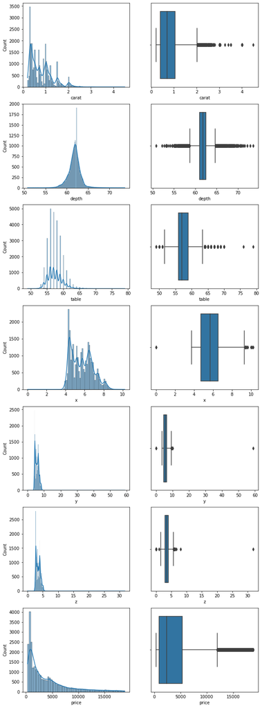

```python
fig, axes = plt.subplots(nrows=7,ncols=2)
fig.set_size_inches(10,30)
sns.histplot(df['carat'], kde=True, ax=axes[0][0])
sns.boxplot(x='carat', data=df, ax=axes[0][1])
sns.histplot(df['depth'] , kde=True, ax=axes[1][0])
sns.boxplot(x='depth', data=df , ax=axes[1][1])
sns.histplot(df['table'] , kde=True, ax=axes[2][0])
sns.boxplot(x='table', data=df , ax=axes[2][1])
sns.histplot(df['x'] , kde=True, ax=axes[3][0])
sns.boxplot(x='x', data=df , ax=axes[3][1])
sns.histplot(df['y'] , kde=True, ax=axes[4][0])
sns.boxplot(x='y', data=df , ax=axes[4][1])
sns.histplot(df['z'] , kde=True, ax=axes[5][0])
sns.boxplot(x='z', data=df , ax=axes[5][1])
sns.histplot(df['price'] , kde=True, ax=axes[6][0])
sns.boxplot(x='price', data=df , ax=axes[6][1])
plt.show()
```

#### Insights:

All fields of carat, depth, table, x, y, z and price have outliers.  
Depth and table are normally distributed, others are right skewed.

#### Categorical Variable

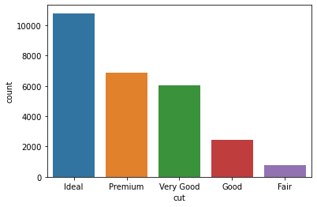

```python
sns.countplot(x='cut', data=df, order=['Ideal', 'Premium', 'Very Good', 'Good', 'Fair'])
```

#### Insights:

“Ideal cut quality” is maximum in cubic zirconia.  
Only few products have “fair cut quality”.

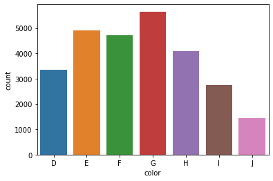

```python
sns.countplot(x='color', data=df, order=['D', 'E', 'F', 'G', 'H', 'I', 'J'])
```

#### Insights:

Maximum color found is “G” in the cubic zirconia.  
Only few products have color “J”. This is the best color.

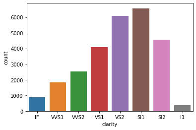

```python
sns.countplot(x='clarity', data=df, order = ['IF', 'VVS1', 'VVS2', 'VS1', 'VS2', 'SI1', 'SI2', 'I1'])
```

#### Insights:

Maximum clarity is SI1 in the cubic zirconia.  
I1 and IF are available in few quantities.

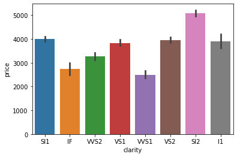

```python
sns.barplot(data = df, x='clarity',y='price')
```

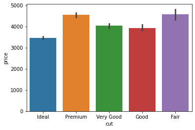

```python
sns.barplot(data = df, x='cut',y='price')
```

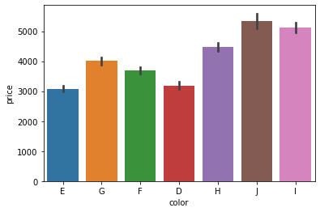

```python
sns.barplot(data = df, x='color',y='price')
```

```python
pd.crosstab(df['cut'], df['color'])
```

| color cut | D | E | F | G | H | I | J |
| --- | --- | --- | --- | --- | --- | --- | --- |
| Fair | 74 | 100 | 148 | 147 | 149 | 94 | 68 |
| Good | 311 | 490 | 453 | 418 | 351 | 252 | 160 |
| Ideal | 1409 | 1966 | 1891 | 2463 | 1550 | 1073 | 453 |
| Premium | 806 | 1174 | 1164 | 1471 | 1159 | 707 | 405 |
| Very Good | 741 | 1186 | 1067 | 1154 | 886 | 639 | 354 |

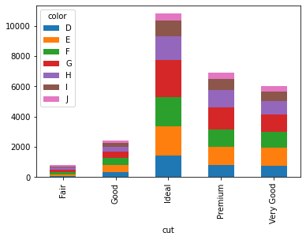

```python
pd.crosstab(df['cut'], df['color']).plot(kind = 'bar', stacked = True)
```

```python
pd.crosstab(df['cut'], df['clarity'])
```

| clarity cut | I1 | IF | SI1 | SI2 | VS1 | VS2 | VVS1 | VVS2 |
| --- | --- | --- | --- | --- | --- | --- | --- | --- |
| Fair | 89 | 4 | 193 | 224 | 93 | 129 | 10 | 38 |
| Good | 50 | 30 | 764 | 527 | 330 | 491 | 100 | 143 |
| Ideal | 74 | 610 | 2146 | 1324 | 1781 | 2527 | 1036 | 1307 |
| Premium | 108 | 115 | 1809 | 1443 | 996 | 1693 | 307 | 415 |
| Very Good | 43 | 132 | 1653 | 1046 | 887 | 1253 | 386 | 627 |

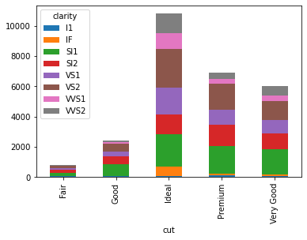

```python
pd.crosstab(df['cut'], df['clarity']).plot(kind = 'bar', stacked = True)
```

### Bivariate Analysis

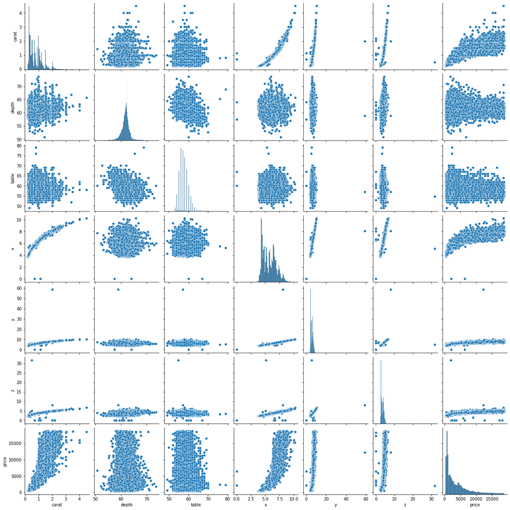

```python
sns.pairplot(df)
plt.show()
```

### Multivariate Analysis

```python
df.corr()
```

|  | carat | depth | table | x | y | z | price |
| --- | --- | --- | --- | --- | --- | --- | --- |
| carat | 1.000000 | 0.035240 | 0.181539 | 0.976858 | 0.941442 | 0.940982 | 0.922409 |
| depth | 0.035240 | 1.000000 | -0.297768 | -0.018401 | -0.024453 | 0.101973 | -0.002895 |
| table | 0.181539 | -0.297768 | 1.000000 | 0.196254 | 0.182352 | 0.148994 | 0.126844 |
| x | 0.976858 | -0.018401 | 0.196254 | 1.000000 | 0.962601 | 0.956490 | 0.886554 |
| y | 0.941442 | -0.024453 | 0.182352 | 0.962601 | 1.000000 | 0.928725 | 0.856441 |
| z | 0.940982 | 0.101973 | 0.148994 | 0.956490 | 0.928725 | 1.000000 | 0.850682 |
| price | 0.922409 | -0.002895 | 0.126844 | 0.886554 | 0.856441 | 0.850682 | 1.000000 |

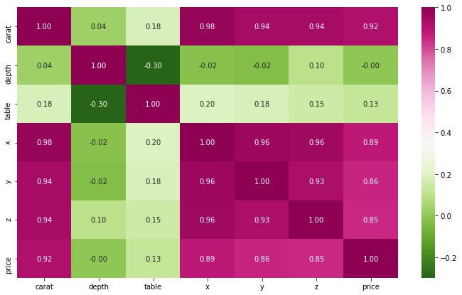

```python
plt.figure(figsize=(12,7))
sns.heatmap(df.corr(), annot=True, fmt='.2f', cmap= 'PiYG_r')
plt.show()
```

As per the heat map there is multi collinearity present in the dataset

High co-relation is present between below variables  
• Carat vs X = 0.98  
• X vs Y, X vs Z = 0.96  
• Carat vs Y, Carat vs Z = 0.94  
• Y vs Z = 0.9

## 1.2 Impute null values if present, also check for the values which are equal to zero. Do they have any meaning or do we need to change them or drop them? Check for the possibility of combining the sub levels of a ordinal variables and take actions accordingly. Explain why you are combining these sub levels with appropriate reasoning.

```python
df.isnull().sum()
```

```
carat        0
cut          0
color        0
clarity      0
depth      697
table        0
x            0
y            0
z            0
price        0
dtype: int64
```

#### Null values present in depth. Since it have outliers, we can't use mean value to replace the null. So, need to replace with median value.

```python
df.depth = df.depth.fillna(df.depth.median())
df[df.depth.isnull()]
```

|  | carat | cut | color | clarity | depth | table | x | y | z | price |
| --- | --- | --- | --- | --- | --- | --- | --- | --- | --- | --- |

#### Checking for that the values is '0'

```python
#Find '0' as a value in all data
df[df['carat'].isin([0])|df['cut'].isin([0])|df['color'].isin([0])|df['clarity'].isin([0])|df['depth'].isin([0])|df['table'].isin([0])|df['x'].isin([0])|df['y'].isin([0])|df['z'].isin([0])|df['price'].isin([0])]
```

|  | carat | cut | color | clarity | depth | table | x | y | z | price |
| --- | --- | --- | --- | --- | --- | --- | --- | --- | --- | --- |
| 5821 | 0.71 | Good | F | SI2 | 64.1 | 60.0 | 0.00 | 0.00 | 0.0 | 2130 |
| 6034 | 2.02 | Premium | H | VS2 | 62.7 | 53.0 | 8.02 | 7.95 | 0.0 | 18207 |
| 10827 | 2.20 | Premium | H | SI1 | 61.2 | 59.0 | 8.42 | 8.37 | 0.0 | 17265 |
| 12498 | 2.18 | Premium | H | SI2 | 59.4 | 61.0 | 8.49 | 8.45 | 0.0 | 12631 |
| 12689 | 1.10 | Premium | G | SI2 | 63.0 | 59.0 | 6.50 | 6.47 | 0.0 | 3696 |
| 17506 | 1.14 | Fair | G | VS1 | 57.5 | 67.0 | 0.00 | 0.00 | 0.0 | 6381 |
| 18194 | 1.01 | Premium | H | I1 | 58.1 | 59.0 | 6.66 | 6.60 | 0.0 | 3167 |
| 23758 | 1.12 | Premium | G | I1 | 60.4 | 59.0 | 6.71 | 6.67 | 0.0 | 2383 |

#### Variables x, y, z are the dimensions of a diamond that have the '0' values in the listed record. As there are very less rows and zero as a value in the dimensions they don't have any meaning in the model. We can drop these rows.

```python
df.drop(df[((df['x'] == 0) | (df['y'] == 0) | (df['z'] == 0))].index, inplace=True)
```

```python
df[df['carat'].isin([0])|df['cut'].isin([0])|df['color'].isin([0])|df['clarity'].isin([0])|df['depth'].isin([0])|df['table'].isin([0])|df['x'].isin([0])|df['y'].isin([0])|df['z'].isin([0])|df['price'].isin([0])]
```

|  | carat | cut | color | clarity | depth | table | x | y | z | price |
| --- | --- | --- | --- | --- | --- | --- | --- | --- | --- | --- |

#### Check for the possibility of combining the sub levels of a ordinal variables and take actions accordingly. Explain why you are combining these sub levels with appropriate reasoning.

Possibility of combining the sub levels for cut variable are good and fair. Both are approximately similar and have less count so the combining for these two will not affect the data separation and reduce the multiple sub levels.

```python
df['cut']=np.where(df['cut'] =='Good', 'Fair', df['cut'])
```

```python
df['cut'].value_counts()
```

```
Ideal        10805
Premium       6880
Very Good     6027
Fair          3213
Name: cut, dtype: int64
```

### Checking for the outliers

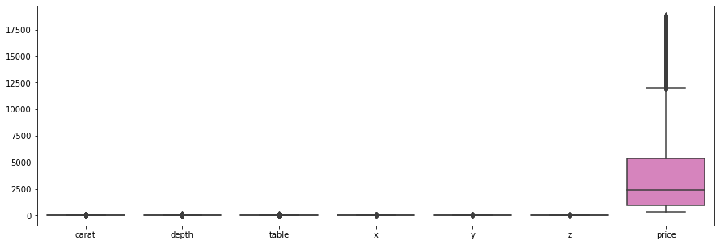

```python
#Check for presence of outliers in unscaled data
plt.figure(figsize=(15,5))
sns.boxplot(data=df)
plt.show()
```

#### Carat, Depth, Table, x, y, z and Price have outliers. We need to treat outliers on the data.

```python
def remove_outlier(col):
    sorted(col)
    Q1,Q3=col.quantile([0.25,0.75])
    IQR=Q3-Q1
    lower_range= Q1-(1.5 * IQR)
    upper_range= Q3+(1.5 * IQR)
    return lower_range, upper_range
```

```python
lrcarat,urcarat=remove_outlier(df['carat'])
df['carat']=np.where(df['carat']>urcarat,urcarat,df['carat'])
df['carat']=np.where(df['carat']<lrcarat,lrcarat,df['carat'])

lrdepth,urdepth=remove_outlier(df['depth'])
df['depth']=np.where(df['depth']>urdepth,urdepth,df['depth'])
df['depth']=np.where(df['depth']<lrdepth,lrdepth,df['depth'])

lrtable,urtable=remove_outlier(df['table'])
df['table']=np.where(df['table']>urtable,urtable,df['table'])
df['table']=np.where(df['table']<lrtable,lrtable,df['table'])

lrx,urx=remove_outlier(df['x'])
df['x']=np.where(df['x']>urx,urx,df['x'])
df['x']=np.where(df['x']<lrx,lrx,df['x'])

lry,ury=remove_outlier(df['y'])
df['y']=np.where(df['y']>ury,ury,df['y'])
df['y']=np.where(df['y']<lry,lry,df['y'])

lrz,urz=remove_outlier(df['z'])
df['z']=np.where(df['z']>urz,urz,df['z'])
df['z']=np.where(df['z']<lrz,lrz,df['z'])

lrprice,urprice=remove_outlier(df['price'])
df['price']=np.where(df['price']>urprice,urprice,df['price'])
df['price']=np.where(df['price']<lrprice,lrprice,df['price'])

df.shape
```

```
(26925, 10)
```

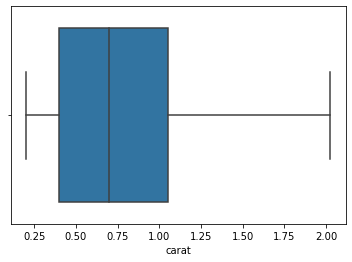

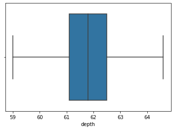

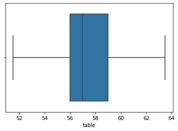

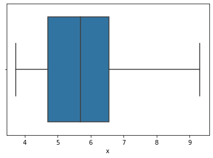

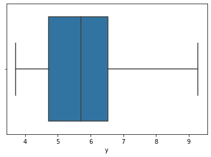

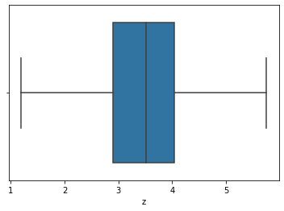

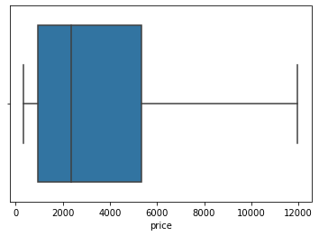

```python
cols = ['carat' ,'depth', 'table', 'x', 'y', 'z',
       'price']

for i in cols:
    sns.boxplot(x=df[i])
    plt.show()
```

#### We need to do scaling as the values of the variables are different.

#### We can use StandardScaler method to scale the dataset. It works to process the data in same scale.

```python
from sklearn.preprocessing import StandardScaler
std_scale = StandardScaler()
std_scale
```

```
StandardScaler()
```

```python
df_scale=df.copy()
```

```python
df_scale['carat'] = std_scale.fit_transform(df_scale[['carat']])
df_scale['depth'] = std_scale.fit_transform(df_scale[['depth']])
df_scale['table'] = std_scale.fit_transform(df_scale[['table']])
df_scale['x'] = std_scale.fit_transform(df_scale[['x']])
df_scale['y']= std_scale.fit_transform(df_scale[['y']])
df_scale['z'] = std_scale.fit_transform(df_scale[['z']])
df_scale['price'] = std_scale.fit_transform(df_scale[['price']])
```

```python
df_scale.head()
```

|  | carat | cut | color | clarity | depth | table | x | y | z | price |
| --- | --- | --- | --- | --- | --- | --- | --- | --- | --- | --- |
| 0 | -1.067382 | Ideal | E | SI1 | 0.286766 | 0.261968 | -1.296530 | -1.289659 | -1.261558 | -0.933395 |
| 1 | -1.002446 | Premium | G | IF | -0.780365 | 0.261968 | -1.163253 | -1.137530 | -1.204060 | -0.793477 |
| 2 | 0.231349 | Very Good | E | VVS2 | 0.368853 | 1.189326 | 0.276134 | 0.347964 | 0.348406 | 0.736960 |
| 3 | -0.807636 | Ideal | F | VS1 | -0.123669 | -0.665390 | -0.807849 | -0.833272 | -0.830318 | -0.765205 |
| 4 | -1.045737 | Ideal | F | VVS1 | -1.108713 | 0.725647 | -1.225449 | -1.164377 | -1.275933 | -0.852618 |

#### We need to do scaling as the values of the variables are different. To get the better result, we need to create a model for the dataset with and without scaling.

### 1.3 Encode the data (having string values) for Modelling. Split the data into train and test (70:30). Apply Linear regression using scikit learn. Perform checks for significant variables using appropriate method from statsmodel. Create multiple models and check the performance of Predictions on Train and Test sets using Rsquare, RMSE & Adj Rsquare. Compare these models and select the best one with appropriate reasoning

### Encode and Linear regression model for scaled data

#### Do label encoding for ordinal categorical variables in data

```python
df2=df_scale.copy()
```

```python
# df2 = pd.get_dummies(df_scale, columns=['cut','color','clarity'],drop_first=True)
df2['cut']=np.where(df2['cut'] =='Fair', '1', df2['cut'])
df2['cut']=np.where(df2['cut'] =='Very Good', '2', df2['cut'])
df2['cut']=np.where(df2['cut'] =='Premium', '3', df2['cut'])
df2['cut']=np.where(df2['cut'] =='Ideal', '4', df2['cut'])
```

```python
df2['color']=np.where(df2['color'] =='D', '1', df2['color'])
df2['color']=np.where(df2['color'] =='E', '2', df2['color'])
df2['color']=np.where(df2['color'] =='F', '3', df2['color'])
df2['color']=np.where(df2['color'] =='G', '4', df2['color'])
df2['color']=np.where(df2['color'] =='H', '5', df2['color'])
df2['color']=np.where(df2['color'] =='I', '6', df2['color'])
df2['color']=np.where(df2['color'] =='J', '7', df2['color'])
```

```python
df2['clarity']=np.where(df2['clarity'] =='IF', '1', df2['clarity'])
df2['clarity']=np.where(df2['clarity'] =='VVS1', '2', df2['clarity'])
df2['clarity']=np.where(df2['clarity'] =='VVS2', '3', df2['clarity'])
df2['clarity']=np.where(df2['clarity'] =='VS1', '4', df2['clarity'])
df2['clarity']=np.where(df2['clarity'] =='VS2', '5', df2['clarity'])
df2['clarity']=np.where(df2['clarity'] =='SI1', '6', df2['clarity'])
df2['clarity']=np.where(df2['clarity'] =='SI2', '7', df2['clarity'])
df2['clarity']=np.where(df2['clarity'] =='I1', '8', df2['clarity'])
```

```python
df2.head()
```

|  | carat | cut | color | clarity | depth | table | x | y | z | price |
| --- | --- | --- | --- | --- | --- | --- | --- | --- | --- | --- |
| 0 | -1.067382 | 4 | 2 | 6 | 0.286766 | 0.261968 | -1.296530 | -1.289659 | -1.261558 | -0.933395 |
| 1 | -1.002446 | 3 | 4 | 1 | -0.780365 | 0.261968 | -1.163253 | -1.137530 | -1.204060 | -0.793477 |
| 2 | 0.231349 | 2 | 2 | 3 | 0.368853 | 1.189326 | 0.276134 | 0.347964 | 0.348406 | 0.736960 |
| 3 | -0.807636 | 4 | 3 | 4 | -0.123669 | -0.665390 | -0.807849 | -0.833272 | -0.830318 | -0.765205 |
| 4 | -1.045737 | 4 | 3 | 2 | -1.108713 | 0.725647 | -1.225449 | -1.164377 | -1.275933 | -0.852618 |

```python
df2.columns
```

```
Index(['carat', 'cut', 'color', 'clarity', 'depth', 'table', 'x', 'y', 'z',
       'price'],
      dtype='object')
```

### Train/ Test split for scaled data

#### Extracting the target column into separate vectors for training set and test set

```python
x = df2.drop('price', axis=1)
y = df2[['price']]
```

#### Splitting data into training and test set

```python
x_train_scale, x_test_scale, y_train_scale, y_test_scale = train_test_split(x, y, test_size=.30, random_state=1)
```

#### Checking the dimensions of the training and test data

```python
print('x_train_scale',x_train_scale.shape)
print('x_test_scale',x_test_scale.shape)
print('y_train_scale',y_train_scale.shape)
print('y_test_scale',y_test_scale.shape)
```

```
x_train_scale (18847, 9)
x_test_scale (8078, 9)
y_train_scale (18847, 1)
y_test_scale (8078, 1)
```

### Linear Regression Model

```python
#Create the LinearRegression function and find the bestfit model on training data

regression_model = LinearRegression()
regression_model.fit(x_train_scale, y_train_scale)
```

```
LinearRegression()
```

```python
# Let us explore the coefficients for each of the independent attributes

for idx, col_name in enumerate(x_train_scale.columns):
    print("The coefficient for {} is {}".format(col_name, regression_model.coef_[0][idx]))
```

```
The coefficient for carat is 1.1846891122320602
The coefficient for cut is 0.03012749481417601
The coefficient for color is -0.07885642739143439
The coefficient for clarity is -0.12625462047633165
The coefficient for depth is 0.011140804608426378
The coefficient for table is -0.011690756161714761
The coefficient for x is -0.4448201715101799
The coefficient for y is 0.5187036176614587
The coefficient for z is -0.20354695576021392
```

```python
# Let us check the intercept for the model

intercept = regression_model.intercept_[0]

print("The intercept for our model is {}".format(intercept))
```

```
The intercept for our model is 0.8199075673363568
```

```python
# R square on training data
regression_model.score(x_train_scale, y_train_scale)
```

```
0.9310131944264549
```

#### 93% of the variation in the price is explained by the predictors in the model for train set

```python
# R square on testing data
regression_model.score(x_test_scale, y_test_scale)
```

```
0.9314012112297532
```

```python
# RMSE on Training data
predicted_train_scale=regression_model.fit(x_train_scale, y_train_scale).predict(x_train_scale)
np.sqrt(metrics.mean_squared_error(y_train_scale, predicted_train_scale))
```

```
0.26204069250036044
```

```python
#RMSE on Testing data
predicted_test_scale=regression_model.fit(x_train_scale, y_train_scale).predict(x_test_scale)
np.sqrt(metrics.mean_squared_error(y_test_scale,predicted_test_scale))
```

```
0.2633313085671723
```

#### Linear Regression using statsmodels

```python
# concatenate x and y into a single dataframe
data_train_scale = pd.concat([x_train_scale, y_train_scale], axis=1)
data_test_scale=pd.concat([x_test_scale, y_test_scale],axis=1)
data_train_scale.head()
```

|  | carat | cut | color | clarity | depth | table | x | y | z | price |
| --- | --- | --- | --- | --- | --- | --- | --- | --- | --- | --- |
| 5030 | 0.664259 | 1 | 2 | 7 | 1.271811 | -0.665390 | 0.711505 | 0.759608 | 0.880269 | 0.095359 |
| 12108 | 0.469450 | 2 | 1 | 7 | 1.846420 | -0.665390 | 0.507147 | 0.580632 | 0.750897 | 0.412986 |
| 20181 | -0.266498 | 1 | 6 | 5 | -0.862452 | 1.838477 | -0.114810 | -0.081576 | -0.183457 | -0.584611 |
| 4712 | -0.071688 | 1 | 4 | 6 | -2.257931 | 2.580364 | 0.285019 | 0.213733 | -0.097209 | -0.371417 |
| 2548 | 0.469450 | 3 | 4 | 4 | 0.861376 | 0.725647 | 0.569343 | 0.544837 | 0.650274 | 0.831873 |

```python
data_train_scale.columns
```

```
Index(['carat', 'cut', 'color', 'clarity', 'depth', 'table', 'x', 'y', 'z',
       'price'],
      dtype='object')
```

```python
expr_scale= 'price ~ carat + depth + table + x + y + z + cut + color + clarity'
```

```python
import statsmodels.formula.api as smf
lm1 = smf.ols(formula= expr_scale, data = data_train_scale).fit()
lm1.params
```

```
Intercept       0.407011
cut[T.2]        0.055518
cut[T.3]        0.087486
cut[T.4]        0.092670
color[T.2]     -0.054146
color[T.3]     -0.066978
color[T.4]     -0.119129
color[T.5]     -0.240242
color[T.6]     -0.384197
color[T.7]     -0.537853
clarity[T.2]   -0.062073
clarity[T.3]   -0.065497
clarity[T.4]   -0.183746
clarity[T.5]   -0.265429
clarity[T.6]   -0.419408
clarity[T.7]   -0.658100
clarity[T.8]   -1.165134
carat           1.224560
depth           0.006738
table          -0.015169
x              -0.442557
y               0.442453
z              -0.161208
dtype: float64
```

```python
print(lm1.summary())
```

```
                            OLS Regression Results
==============================================================================
Dep. Variable:                  price   R-squared:                       0.940
Model:                            OLS   Adj. R-squared:                  0.940
Method:                 Least Squares   F-statistic:                 1.346e+04
Date:                Sat, 02 Oct 2021   Prob (F-statistic):               0.00
Time:                        13:50:21   Log-Likelihood:                -150.75
No. Observations:               18847   AIC:                             347.5
Df Residuals:                   18824   BIC:                             527.9
Df Model:                          22
Covariance Type:            nonrobust
================================================================================
                   coef    std err          t      P>|t|      [0.025      0.975]
--------------------------------------------------------------------------------
Intercept        0.4070      0.013     32.376      0.000       0.382       0.432
cut[T.2]         0.0555      0.007      8.258      0.000       0.042       0.069
cut[T.3]         0.0875      0.007     12.826      0.000       0.074       0.101
cut[T.4]         0.0927      0.007     13.049      0.000       0.079       0.107
color[T.2]      -0.0541      0.007     -8.249      0.000      -0.067      -0.041
color[T.3]      -0.0670      0.007    -10.066      0.000      -0.080      -0.054
color[T.4]      -0.1191      0.007    -18.313      0.000      -0.132      -0.106
color[T.5]      -0.2402      0.007    -34.629      0.000      -0.254      -0.227
color[T.6]      -0.3842      0.008    -49.676      0.000      -0.399      -0.369
color[T.7]      -0.5379      0.009    -56.791      0.000      -0.556      -0.519
clarity[T.2]    -0.0621      0.012     -5.227      0.000      -0.085      -0.039
clarity[T.3]    -0.0655      0.011     -5.777      0.000      -0.088      -0.043
clarity[T.4]    -0.1837      0.011    -16.987      0.000      -0.205      -0.163
clarity[T.5]    -0.2654      0.011    -25.111      0.000      -0.286      -0.245
clarity[T.6]    -0.4194      0.011    -39.371      0.000      -0.440      -0.399
clarity[T.7]    -0.6581      0.011    -59.340      0.000      -0.680      -0.636
clarity[T.8]    -1.1651      0.019    -62.281      0.000      -1.202      -1.128
carat            1.2246      0.010    118.504      0.000       1.204       1.245
depth            0.0067      0.004      1.833      0.067      -0.000       0.014
table           -0.0152      0.002     -6.351      0.000      -0.020      -0.010
x               -0.4426      0.044    -10.088      0.000      -0.529      -0.357
y                0.4425      0.043     10.208      0.000       0.357       0.527
z               -0.1612      0.026     -6.177      0.000      -0.212      -0.110
==============================================================================
Omnibus:                     4593.950   Durbin-Watson:                   2.003
Prob(Omnibus):                  0.000   Jarque-Bera (JB):            17072.955
Skew:                           1.186   Prob(JB):                         0.00
Kurtosis:                       7.014   Cond. No.                         66.2
==============================================================================

Notes:
[1] Standard Errors assume that the covariance matrix of the errors is correctly specified.
```

```python
# Calculate MSE
mse = np.mean((lm1.predict(data_train_scale.drop('price',axis=1))-data_train_scale['price'])**2)
```

```python
#Root Mean Squared Error - RMSE
np.sqrt(mse)
```

```
0.24391396666679335
```

```python
np.sqrt(lm1.mse_resid) #another way
```

```
0.24406293364076606
```

```python
# Prediction on Test data
y_pred_scale = lm1.predict(data_test_scale)
```

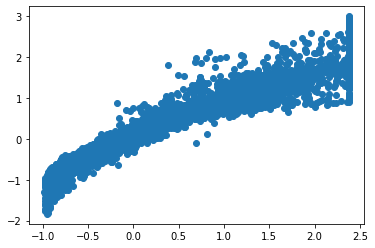

```python
plt.scatter(y_test_scale['price'], y_pred_scale)
plt.show()
```

```python
for i,j in np.array(lm1.params.reset_index()):
    print('({}) * {} +'.format(round(j,2),i),end=' ')
```

[output not shown]

### Encode and Linear regression model for unscaled data

#### Converting ordinal categorical variable to continuous varible by label encoding in data

```python
df3=df.copy()
```

```python
df3['cut']=np.where(df3['cut'] =='Fair', '1', df3['cut'])
df3['cut']=np.where(df3['cut'] =='Very Good', '2', df3['cut'])
df3['cut']=np.where(df3['cut'] =='Premium', '3', df3['cut'])
df3['cut']=np.where(df3['cut'] =='Ideal', '4', df3['cut'])
```

```python
df3['color']=np.where(df3['color'] =='D', '1', df3['color'])
df3['color']=np.where(df3['color'] =='E', '2', df3['color'])
df3['color']=np.where(df3['color'] =='F', '3', df3['color'])
df3['color']=np.where(df3['color'] =='G', '4', df3['color'])
df3['color']=np.where(df3['color'] =='H', '5', df3['color'])
df3['color']=np.where(df3['color'] =='I', '6', df3['color'])
df3['color']=np.where(df3['color'] =='J', '7', df3['color'])
```

```python
df3['clarity']=np.where(df3['clarity'] =='IF', '1', df3['clarity'])
df3['clarity']=np.where(df3['clarity'] =='VVS1', '2', df3['clarity'])
df3['clarity']=np.where(df3['clarity'] =='VVS2', '3', df3['clarity'])
df3['clarity']=np.where(df3['clarity'] =='VS1', '4', df3['clarity'])
df3['clarity']=np.where(df3['clarity'] =='VS2', '5', df3['clarity'])
df3['clarity']=np.where(df3['clarity'] =='SI1', '6', df3['clarity'])
df3['clarity']=np.where(df3['clarity'] =='SI2', '7', df3['clarity'])
df3['clarity']=np.where(df3['clarity'] =='I1', '8', df3['clarity'])
```

```python
df3.head()
```

|  | carat | cut | color | clarity | depth | table | x | y | z | price |
| --- | --- | --- | --- | --- | --- | --- | --- | --- | --- | --- |
| 0 | 0.30 | 4 | 2 | 6 | 62.1 | 58.0 | 4.27 | 4.29 | 2.66 | 499.0 |
| 1 | 0.33 | 3 | 4 | 1 | 60.8 | 58.0 | 4.42 | 4.46 | 2.70 | 984.0 |
| 2 | 0.90 | 2 | 2 | 3 | 62.2 | 60.0 | 6.04 | 6.12 | 3.78 | 6289.0 |
| 3 | 0.42 | 4 | 3 | 4 | 61.6 | 56.0 | 4.82 | 4.80 | 2.96 | 1082.0 |
| 4 | 0.31 | 4 | 3 | 2 | 60.4 | 59.0 | 4.35 | 4.43 | 2.65 | 779.0 |

```python
df3.columns
```

```
Index(['carat', 'cut', 'color', 'clarity', 'depth', 'table', 'x', 'y', 'z',
       'price'],
      dtype='object')
```

#### Extracting the target column into separate vectors for training set and test set

```python
x = df3.drop('price', axis=1)
y = df3[['price']]
```

#### Splitting data into training and test set

```python
x_train, x_test, y_train, y_test = train_test_split(x, y, test_size=.30, random_state=1)
```

#### Checking the dimensions of the training and test data

```python
print('x_train',x_train.shape)
print('x_test',x_test.shape)
print('y_train',y_train.shape)
print('y_test',y_test.shape)
```

```
x_train (18847, 9)
x_test (8078, 9)
y_train (18847, 1)
y_test (8078, 1)
```

### Linear Regression Model

```python
#Create the LinearRegression function and find the bestfit model on training data

regression_model = LinearRegression()
regression_model.fit(x_train, y_train)
```

```
LinearRegression()
```

```python
# Let us explore the coefficients for each of the independent attributes

for idx, col_name in enumerate(x_train.columns):
    print("The coefficient for {} is {}".format(col_name, regression_model.coef_[0][idx]))
```

```
The coefficient for carat is 8888.78518643631
The coefficient for cut is 104.43184969443155
The coefficient for color is -273.3424276918965
The coefficient for clarity is -437.64022299681824
The coefficient for depth is 31.700124320956526
The coefficient for table is -18.790146279612514
The coefficient for x is -1369.9891569746158
The coefficient for y is 1608.9859894697329
The coefficient for z is -1014.2214415029238
```

```python
# Let us check the intercept for the model

intercept = regression_model.intercept_[0]
print("The intercept for our model is {}".format(intercept))
```

```
The intercept for our model is 863.9124992315005
```

```python
# R square on training data
regression_model.score(x_train, y_train)
```

```
0.9310131944264549
```

```python
# R square on testing data
regression_model.score(x_test, y_test)
```

```
0.9314012112297532
```

```python
# RMSE on Training data
predicted_train=regression_model.fit(x_train, y_train).predict(x_train)
np.sqrt(metrics.mean_squared_error(y_train, predicted_train))
```

```
908.3196057889741
```

```python
#RMSE on Testing data
predicted_test=regression_model.fit(x_train, y_train).predict(x_test)
np.sqrt(metrics.mean_squared_error(y_test,predicted_test))
```

```
912.7933074337279
```

### Linear Regression using statsmodels

```python
# concatenate x and y into a single dataframe
data_train = pd.concat([x_train, y_train], axis=1)
data_test = pd.concat([x_test, y_test],axis=1)
data_train.head()
```

|  | carat | cut | color | clarity | depth | table | x | y | z | price |
| --- | --- | --- | --- | --- | --- | --- | --- | --- | --- | --- |
| 5030 | 1.10 | 1 | 2 | 7 | 63.3 | 56.0 | 6.53 | 6.58 | 4.15 | 4065.0 |
| 12108 | 1.01 | 2 | 1 | 7 | 64.0 | 56.0 | 6.30 | 6.38 | 4.06 | 5166.0 |
| 20181 | 0.67 | 1 | 6 | 5 | 60.7 | 61.4 | 5.60 | 5.64 | 3.41 | 1708.0 |
| 4712 | 0.76 | 1 | 4 | 6 | 59.0 | 63.0 | 6.05 | 5.97 | 3.47 | 2447.0 |
| 2548 | 1.01 | 3 | 4 | 4 | 62.8 | 59.0 | 6.37 | 6.34 | 3.99 | 6618.0 |

```python
data_train.columns
```

```
Index(['carat', 'cut', 'color', 'clarity', 'depth', 'table', 'x', 'y', 'z',
       'price'],
      dtype='object')
```

```python
expr= 'price ~ carat + depth + table + x + y + z + cut + color + clarity'
```

```python
import statsmodels.formula.api as smf
lm2 = smf.ols(formula= expr, data = data_train).fit()
lm2.params
```

```
Intercept        859.414472
cut[T.2]         192.442973
cut[T.3]         303.255948
cut[T.4]         321.223552
color[T.2]      -187.689226
color[T.3]      -232.167049
color[T.4]      -412.938744
color[T.5]      -832.758693
color[T.6]     -1331.754381
color[T.7]     -1864.377744
clarity[T.2]    -215.166779
clarity[T.3]    -227.032944
clarity[T.4]    -636.923715
clarity[T.5]    -920.064944
clarity[T.6]   -1453.805387
clarity[T.7]   -2281.191680
clarity[T.8]   -4038.740015
carat           9187.941659
depth             19.172308
table            -24.380519
x              -1363.019874
y               1372.459912
z               -803.255496
dtype: float64
```

```python
print(lm2.summary())
```

```
                            OLS Regression Results
==============================================================================
Dep. Variable:                  price   R-squared:                       0.940
Model:                            OLS   Adj. R-squared:                  0.940
Method:                 Least Squares   F-statistic:                 1.346e+04
Date:                Sat, 02 Oct 2021   Prob (F-statistic):               0.00
Time:                        14:04:43   Log-Likelihood:            -1.5377e+05
No. Observations:               18847   AIC:                         3.076e+05
Df Residuals:                   18824   BIC:                         3.078e+05
Df Model:                          22
Covariance Type:            nonrobust
================================================================================
                   coef    std err          t      P>|t|      [0.025      0.975]
--------------------------------------------------------------------------------
Intercept      859.4145    748.880      1.148      0.251    -608.457    2327.286
cut[T.2]       192.4430     23.303      8.258      0.000     146.766     238.120
cut[T.3]       303.2559     23.645     12.826      0.000     256.910     349.602
cut[T.4]       321.2236     24.616     13.049      0.000     272.974     369.473
color[T.2]    -187.6892     22.752     -8.249      0.000    -232.285    -143.093
color[T.3]    -232.1670     23.064    -10.066      0.000    -277.374    -186.960
color[T.4]    -412.9387     22.549    -18.313      0.000    -457.137    -368.740
color[T.5]    -832.7587     24.048    -34.629      0.000    -879.895    -785.622
color[T.6]   -1331.7544     26.809    -49.676      0.000   -1384.302   -1279.207
color[T.7]   -1864.3777     32.829    -56.791      0.000   -1928.726   -1800.030
clarity[T.2]  -215.1668     41.166     -5.227      0.000    -295.855    -134.479
clarity[T.3]  -227.0329     39.299     -5.777      0.000    -304.063    -150.003
clarity[T.4]  -636.9237     37.495    -16.987      0.000    -710.418    -563.429
clarity[T.5]  -920.0649     36.640    -25.111      0.000    -991.883    -848.247
clarity[T.6] -1453.8054     36.925    -39.371      0.000   -1526.182   -1381.428
clarity[T.7] -2281.1917     38.443    -59.340      0.000   -2356.543   -2205.841
clarity[T.8] -4038.7400     64.847    -62.281      0.000   -4165.846   -3911.634
carat         9187.9417     77.533    118.504      0.000    9035.970    9339.913
depth           19.1723     10.457      1.833      0.067      -1.325      39.670
table          -24.3805      3.839     -6.351      0.000     -31.905     -16.857
x            -1363.0199    135.109    -10.088      0.000   -1627.845   -1098.195
y             1372.4599    134.448     10.208      0.000    1108.931    1635.989
z             -803.2555    130.047     -6.177      0.000   -1058.160    -548.351
==============================================================================
Omnibus:                     4593.950   Durbin-Watson:                   2.003
Prob(Omnibus):                  0.000   Jarque-Bera (JB):            17072.955
Skew:                           1.186   Prob(JB):                         0.00
Kurtosis:                       7.014   Cond. No.                     1.04e+04
==============================================================================

Notes:
[1] Standard Errors assume that the covariance matrix of the errors is correctly specified.
[2] The condition number is large, 1.04e+04. This might indicate that there are
strong multicollinearity or other numerical problems.
```

```python
# Calculate MSE
mse = np.mean((lm2.predict(data_train.drop('price',axis=1))-data_train['price'])**2)
```

```python
#Root Mean Squared Error - RMSE
np.sqrt(mse)
```

```
845.4863858555202
```

```python
np.sqrt(lm2.mse_resid) #another way
```

```
846.0027545987966
```

```python
# Prediction on Test data
y_pred = lm2.predict(data_test)
```

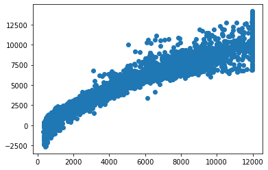

```python
plt.scatter(y_test['price'], y_pred)
plt.show()
```

```python
for i,j in np.array(lm2.params.reset_index()):
    print('({}) * {} +'.format(round(j,2),i),end=' ')
```

[output not shown]

### 1.4 Inference: Basis on these predictions, what are the business insights and recommendations

Please explain and summarise the various steps performed in this project. There should be proper business interpretation and actionable insights present.

Using stats model same 94% of R-squared and Adj.R-squared were predicted. As per P values and coefficients, we will be understanding the relationship. For the values more than 0.05, we can drop these variables for better results. Therefore for better accuracy we can drop the depth column.

#### The final Linear Regression equation is

b0 *Intercept + b1* cut[T.2] + b2 *cut[T.3] + b3* cut[T.4] + b4 *color[T.2] + b5* color[T.3] + b6 *color[T.4] + b7* color[T.5] + b8 *color[T.6] + b9* color[T.7] + b10 *clarity[T.2] + b11* clarity[T.3] + b12 *clarity[T.4] + b13* clarity[T.5] + b14 *clarity[T.6] + b15* clarity[T.7] + b16 *clarity[T.8] + b17* carat + b18 *depth + b19* table + b20 *x + b21* y + b22 * z

#### For scaled data

(0.41) *Intercept + (0.06)* cut[T.2] + (0.09) *cut[T.3] + (0.09)* cut[T.4] + (-0.05) *color[T.2] + (-0.07)* color[T.3] + (-0.12) *color[T.4] + (-0.24)* color[T.5] + (-0.38) *color[T.6] + (-0.54)* color[T.7] + (-0.06) *clarity[T.2] + (-0.07)* clarity[T.3] + (-0.18) *clarity[T.4] + (-0.27)* clarity[T.5] + (-0.42) *clarity[T.6] + (-0.66)* clarity[T.7] + (-1.17) *clarity[T.8] + (1.22)* carat + (0.01) *depth + (-0.02)* table + (-0.44) *x + (0.44)* y + (-0.16) * z

#### For unscaled data

(859.41) *Intercept + (192.44)* cut[T.2] + (303.26) *cut[T.3] + (321.22)* cut[T.4] + (-187.69) *color[T.2] + (-232.17)* color[T.3] + (-412.94) *color[T.4] + (-832.76)* color[T.5] + (-1331.75) *color[T.6] + (-1864.38)* color[T.7] + (-215.17) *clarity[T.2] + (-227.03)* clarity[T.3] + (-636.92) *clarity[T.4] + (-920.06)* clarity[T.5] + (-1453.81) *clarity[T.6] + (-2281.19)* clarity[T.7] + (-4038.74) *clarity[T.8] + (9187.94)* carat + (19.17) *depth + (-24.38)* table + (-1363.02) *x + (1372.46)* y + (-803.26) * z

As per the RMSE value and coefficient of the each variable, we can use scaled data for prediction. There is also multi collinearity presence in the unscaled data.

# Problem 2: Logistic Regression and LDA

You are hired by a tour and travel agency which deals in selling holiday packages. You are provided details of 872 employees of a company. Among these employees, some opted for the package and some didn't. You have to help the company in predicting whether an employee will opt for the package or not on the basis of the information given in the data set. Also, find out the important factors on the basis of which the company will focus on particular employees to sell their packages.

### Data Dictionary:

**Variable Name - Description**  
**Holiday_Package** - Opted for Holiday Package yes/no?  
**Salary** - Employee salary  
**age** - Age in years  
**edu** - Years of formal education  
**no_young_children** - The number of young children (younger than 7 years)  
**no_older_children** - Number of older children  
**foreign** - foreigner Yes/No